# Demonstation program for module 05

## Summary for continuous variables: ht

```r
pulmonary_1 |>
  summarize(
    ht_mean=mean(ht),
    ht_sd=sd(ht),
    ht_min=min(ht),
    ht_max=max(ht)) |>
  gt() |>
  tab_header(md("**Descriptive statistics**")) |>
  tab_source_note("Simon, 2025-04-20") |>
  fmt_number(n_sigfig=3)
```

**Descriptive statistics**

| ht_mean | ht_sd | ht_min | ht_max |
| --- | --- | --- | --- |
| 61.1 | 5.70 | 46.0 | 74.0 |

Simon, 2025-04-20

#### Interpretation of the output

Again, these seem to be reasonable values.

## Summary for categorical variables: sex

```r
pulmonary_1 |>
  count(sex) |>
  mutate(total=sum(n)) |>
  mutate(pct=round(100*n/total)) |>
  mutate(pct=glue("{n}/{total} ({pct}%)")) |>
  gt() |>
  tab_header(md("**Descriptive statistics**")) |>
  tab_source_note("Simon, 2025-04-20")
```

**Descriptive statistics**

| sex | n | total | pct |
| --- | --- | --- | --- |
| female | 318 | 654 | 318/654 (49%) |
| male | 336 | 654 | 336/654 (51%) |

Simon, 2025-04-20

#### Interpretation of the output

The patients are split almost evenly with slightly more males than females.

## Summary for categorical variables: smoke

```r
pulmonary_1 |>
  count(smoke) |>
  mutate(total=sum(n)) |>
  mutate(pct=round(100*n/total)) |>
  mutate(pct=glue("{n}/{total} ({pct}%)")) |>
  select(-n, -total) |>
  gt() |>
  tab_header(md("**Descriptive statistics**")) |>
  tab_source_note("Simon, 2025-04-20")
```

**Descriptive statistics**

| smoke | pct |
| --- | --- |
| nonsmoker | 589/654 (90%) |
| smoker | 65/654 (10%) |

Simon, 2025-04-20

#### Interpretation of the output

Only a small fraction (10%) of the patients are smokers.

# — Begin part 2 —

## Group means, fev-by-sex

```r
pulmonary_1 |>
  group_by(sex) |>
  summarize(
    fev_mean=mean(fev),
    fev_sd=sd(fev)) |>
  gt() |>
  tab_header(md("**Descriptive statistics**")) |>
  tab_source_note("Simon, 2025-04-20")
```

**Descriptive statistics**

| sex | fev_mean | fev_sd |
| --- | --- | --- |
| female | 2.451170 | 0.645736 |
| male | 2.812446 | 1.003598 |

Simon, 2025-04-20

#### Interpretation of the output

## Group means, fev-by-smoke

```r
pulmonary_1 |>
  group_by(smoke) |>
  summarize(
    fev_mean=mean(fev),
    fev_sd=sd(fev)) |>
  gt() |>
  tab_header(md("**Group means**")) |>
  tab_source_note("Simon, 2025-04-20") |>
  fmt_number(n_sigfig=3)
```

**Group means**

| smoke | fev_mean | fev_sd |
| --- | --- | --- |
| nonsmoker | 2.57 | 0.851 |
| smoker | 3.28 | 0.750 |

Simon, 2025-04-20

#### Interpretation of the output

## Group means, age-by-smoke

```r
pulmonary_1 |>
  group_by(smoke) |>
  summarize(
    age_mean=mean(age),
    age_sd=sd(age)) |>
  gt() |>
  tab_header(md("**Group means**")) |>
  tab_source_note("Simon, 2025-04-20") |>
  fmt_number(n_sigfig=3)
```

**Group means**

| smoke | age_mean | age_sd |
| --- | --- | --- |
| nonsmoker | 9.53 | 2.74 |
| smoker | 13.5 | 2.34 |

Simon, 2025-04-20

#### Interpretation of the output

# — Begin part 3 —

## Scatterplot

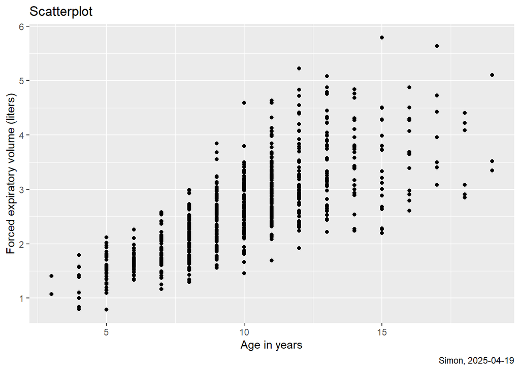

```r
pulmonary_1 |>
  ggplot() +
  aes(x=age, y=fev) +
  geom_point() +
  labs(
    title="Scatterplot",
    x="Age in years",
    y="Forced expiratory volume (liters)",
    caption="Simon, 2025-04-19") -> plot_1

plot_1
```

#### Inpterpretation of the output

There is a strong positive relationship between age and fev.

Recall that you use a scatterplot to examine the relationship between two continuous variables.

## Crosstabs

```r
pulmonary_1 |>
  count(sex, smoke) |>
  group_by(sex) |>
  mutate(total=sum(n)) |>
  mutate(pct=round(100*n/total)) |>
  mutate(pct=glue("{n}/{total} ({pct}%)")) |>
  select(-n, -total) |>
  pivot_wider(
    names_from=smoke,
    values_from=pct) |>
  gt() |>
  tab_header(md("**Crosstabulation**")) |>
  tab_source_note("Simon, 2025-04-20")
```

**Crosstabulation**

[output not shown]

Simon, 2025-04-20

#### Comments on the code

The [tab_header](https://gt.rstudio.com/reference/tab_header.html) and [tab_source_note](https://gt.rstudio.com/reference/tab_source_note.html) functions place text at the top and bottom of a table, respectively. I suggest that you provide a very brief explanatory title at the top and your name and date at the bottom.

## Create factors

```r
pulmonary |>
  mutate(smoke=factor(
    smoke,
    levels=0:1,
    labels=c("nonsmoker", "smoker"))) |>
  mutate(sex=factor(
    sex,
    levels=0:1,
    labels=c("female", "male"))) -> pulmonary_1
```

## Summary for continuous variables: age

```r
pulmonary_1 |>
  summarize(
    age_mean=mean(age),
    age_sd=sd(age),
    age_min=min(age),
    age_max=max(age)) -> table_02

table_02 |>
  gt() |>
  tab_header(md("**Descriptive statistics**")) |>
  tab_source_note("Simon, 2025-04-20") |>
  fmt_number(columns=1:2, n_sigfig=2)
```

**Descriptive statistics**

| age_mean | age_sd | age_min | age_max |
| --- | --- | --- | --- |
| 9.9 | 3.0 | 3 | 19 |

Simon, 2025-04-20

#### Comments on the code

The [fmt_number](https://gt.rstudio.com/reference/fmt_number.html) function allows you to specify how numbers are displayed. The n_sigfig argument controls how many significant digits your numbers are rounded to. The columns argument restricts rounding to specific columns.

#### Interpretation of the output

This is clearly a pediatric population.

## Summary for continuous variables: fev

```r
pulmonary_1 |>
  summarize(
    fev_mean=mean(fev),
    fev_sd=sd(fev),
    fev_min=min(fev),
    fev_max=max(fev)) -> table_03

table_03 |>
  gt() |>
  tab_header(md("**Descriptive statistics**")) |>
  tab_source_note("Simon, 2025-04-20") |>
  fmt_number(columns=1:2, n_sigfig=2)
```

**Descriptive statistics**

| fev_mean | fev_sd | fev_min | fev_max |
| --- | --- | --- | --- |
| 2.6 | 0.87 | 0.791 | 5.793 |

Simon, 2025-04-20

#### Interpretation of the output

I am not an expert on FEV, but these values seem reasonable.

## Summary for continuous variables: ht

```r
pulmonary_1 |>
  summarize(
    ht_mean=mean(ht),
    ht_sd=sd(ht),
    ht_min=min(ht),
    ht_max=max(ht)) -> table_04

table_04 |>
  gt() |>
  tab_header(md("**Descriptive statistics**")) |>
  tab_source_note("Simon, 2025-04-20") |>
  fmt_number(columns=1:2, n_sigfig=2)
```

**Descriptive statistics**

| ht_mean | ht_sd | ht_min | ht_max |
| --- | --- | --- | --- |
| 61 | 5.7 | 46 | 74 |

Simon, 2025-04-20

#### Interpretation of the output

Again, these seem to be reasonable values.

## Summary for categorical variables: sex

```r
pulmonary_1 |>
  count(sex) |>
  mutate(total=sum(n)) |>
  mutate(pct=round(100*n/total)) |>
  mutate(pct=glue("{n}/{total} ({pct}%)")) -> table_05

table_05 |>
  gt() |>
  tab_header(md("**Descriptive statistics**")) |>
  tab_source_note("Simon, 2025-04-20")
```

**Descriptive statistics**

| sex | n | total | pct |
| --- | --- | --- | --- |
| female | 318 | 654 | 318/654 (49%) |
| male | 336 | 654 | 336/654 (51%) |

Simon, 2025-04-20

#### Interpretation of the output

The patients are split almost evenly with slightly more males than females.

## Summary for categorical variables: smoke

```r
pulmonary_1 |>
  count(smoke) |>
  mutate(total=sum(n)) |>
  mutate(pct=round(100*n/total)) |>
  mutate(pct=glue("{n}/{total} ({pct}%)")) -> table_06

table_06 |>
  gt() |>
  tab_header(md("**Descriptive statistics**")) |>
  tab_source_note("Simon, 2025-04-20")
```

**Descriptive statistics**

| smoke | n | total | pct |
| --- | --- | --- | --- |
| nonsmoker | 589 | 654 | 589/654 (90%) |
| smoker | 65 | 654 | 65/654 (10%) |

Simon, 2025-04-20

#### Interpretation of the output

Only a small fraction (10%) of the patients are smokers.

# — Begin part 2 —

## Group means, fev-by-sex

```r
pulmonary_1 |>
  group_by(sex) |>
  summarize(
    fev_mean=mean(fev),
    fev_sd=sd(fev),
    n=n()) -> table_07

table_07 |>
  gt() |>
  tab_header(md("**Group statistics**")) |>
  tab_source_note("Simon, 2025-04-20") |>
  fmt_number(columns=1:2, n_sigfig=2)
```

**Group statistics**

| sex | fev_mean | fev_sd | n |
| --- | --- | --- | --- |
| female | 2.5 | 0.645736 | 318 |
| male | 2.8 | 1.003598 | 336 |

Simon, 2025-04-20

#### Interpretation of the output

## Group means, fev-by-smoke

```r
pulmonary_1 |>
  group_by(smoke) |>
  summarize(
    fev_mean=mean(fev),
    fev_sd=sd(fev),
    n=n()) -> table_08

table_08 |>
  gt() |>
  tab_header(md("**Group statistics**")) |>
  tab_source_note("Simon, 2025-04-20") |>
    fmt_number(columns=1:2, n_sigfig=2)
```

**Group statistics**

| smoke | fev_mean | fev_sd | n |
| --- | --- | --- | --- |
| nonsmoker | 2.6 | 0.8505215 | 589 |
| smoker | 3.3 | 0.7499863 | 65 |

Simon, 2025-04-20

#### Interpretation of the output

## Group means, age-by-smoke

```r
pulmonary_1 |>
  group_by(smoke) |>
  summarize(
    age_mean=mean(age),
    age_sd=sd(age),
    n=n())  -> table_09

table_09 |>
  gt() |>
  tab_header(md("**Group statistics**")) |>
  tab_source_note("Simon, 2025-04-20") |>
    fmt_number(columns=1:2, n_sigfig=2)
```

**Group statistics**

| smoke | age_mean | age_sd | n |
| --- | --- | --- | --- |
| nonsmoker | 9.5 | 2.740642 | 589 |
| smoker | 14 | 2.339255 | 65 |

Simon, 2025-04-20

#### Interpretation of the output

# — Begin part 3 —

## Scatterplot

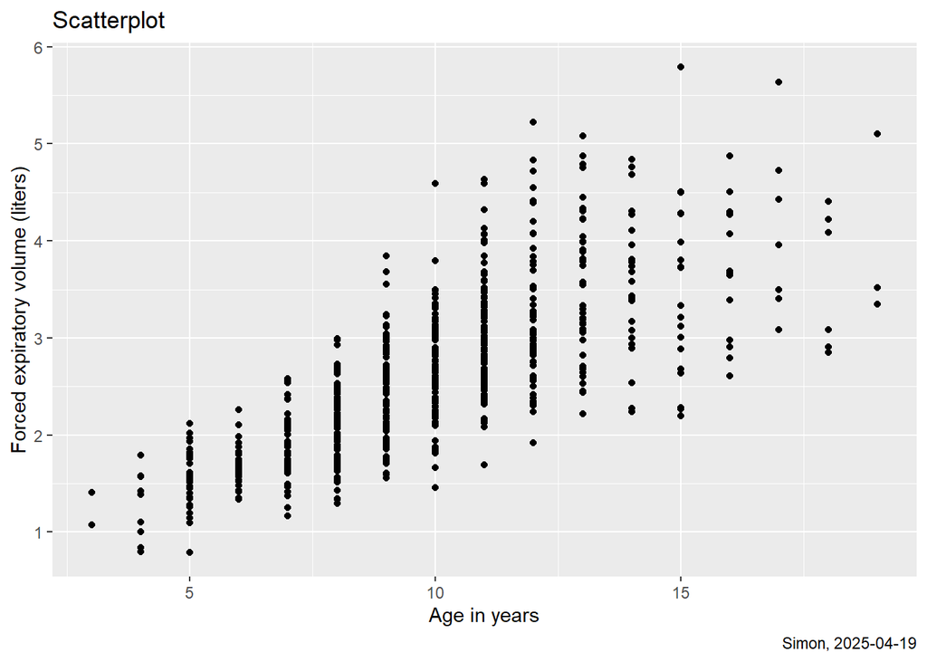

```r
pulmonary_1 |>
  ggplot() +
  aes(x=age, y=fev) +
  geom_point() +
  labs(
    title="Scatterplot",
    x="Age in years",
    y="Forced expiratory volume (liters)",
    caption="Simon, 2025-04-19") -> plot_01

plot_01
```

#### Inpterpretation of the output

There is a strong positive relationship between age and fev.

Recall that you use a scatterplot to examine the relationship between two continuous variables.

## Crosstabs

```r
pulmonary_1 |>
  count(sex, smoke) |>
  group_by(sex) |>
  mutate(total=sum(n)) |>
  mutate(pct=round(100*n/total)) |>
  mutate(pct=glue("{n}/{total} ({pct}%)")) |>
  select(-n, -total) -> table_10

table_10 |>
  pivot_wider(
    names_from=smoke,
    values_from=pct) |>
    ungroup() |>
  gt() |>
  tab_header(md("**Crosstabulation**")) |>
  tab_source_note("Simon, 2025-04-20")
```

**Crosstabulation**

| sex | nonsmoker | smoker |
| --- | --- | --- |
| female | 279/318 (88%) | 39/318 (12%) |
| male | 310/336 (92%) | 26/336 (8%) |

Simon, 2025-04-20

#### Interpretation of the output

Smoking is uncommon but occurs slightly more often with female patients.

## Boxplots

[figure not shown]

Interpretation of the output

```r
pulmonary_1 |>
  ggplot() +
  aes(x=smoke, y=fev) +
  geom_boxplot() +
  coord_flip() +
  labs(
    title="Boxplots",
    x="Smoking status",
    y="Forced expiratory volume (liters)",
    caption="Simon, 2025-04-19") -> plot_02

plot_02
```

## Boxplots

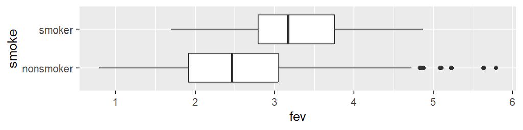

```r
pulmonary_1 |>
  ggplot() +
  aes(x=smoke, y=fev) +
  geom_boxplot() +
  coord_flip()
```

```r
  labs(
    title="Boxplots",
    x="Smoking status",
    y="Forced expiratory volume (liters)",
    caption="Simon, 2025-04-19") -> plot_2

plot_2
```

[output not shown]

#### Comments on the code

Boxplots, especially for a small number of levels of your categorical variable, tend to look nicer flipped horizontally and with a fairly small height.

#### Interpretation of the output

In a bit of a surprise, fev values tend to be higher for smokers than for non-smokers.

## Clustered boxplots, 1

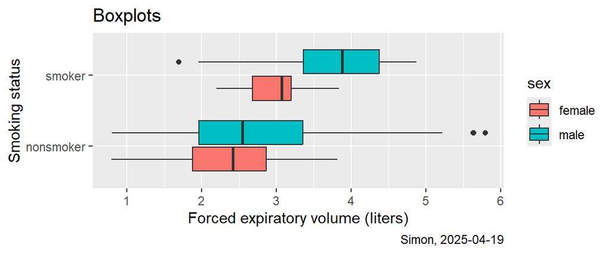

```r
pulmonary_1 |>
  ggplot() +
  aes(x=smoke, y=fev, fill=sex) +
  geom_boxplot() +
  coord_flip() +
  labs(
    title="Boxplots",
    x="Smoking status",
    y="Forced expiratory volume (liters)",
    caption="Simon, 2025-04-19") -> plot_3

plot_3
```

#### Comments on the code

Boxplots, especially for a small number of levels of your categorical variable, tend to look nicer flipped horizontally and with a fairly small height.

#### Interpretation of the output

In a bit of a surprise, fev values tend to be higher for smokers than for non-smokers.

## Clustered boxplots, 1

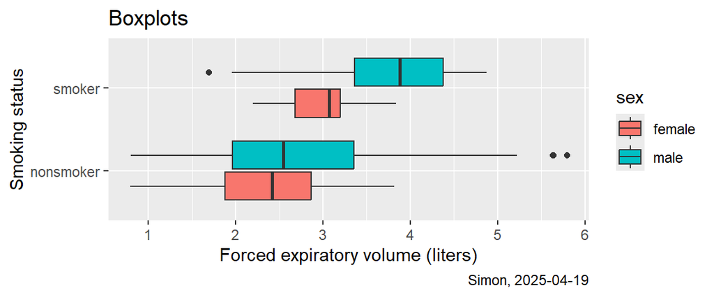

```r
pulmonary_1 |>
  ggplot() +
  aes(x=smoke, y=fev, fill=sex) +
  geom_boxplot() +
  coord_flip() +
  labs(
    title="Boxplots",
    x="Smoking status",
    y="Forced expiratory volume (liters)",
    caption="Simon, 2025-04-19") -> plot_03

plot_03
```

#### Comments on the code

Specifying the fill argument tells ggplot that you want to further break down your boxplots by a second categorical variable, sex.

## Clustered boxplots, 2

```r
pulmonary_1 |>
  ggplot() +
  aes(x=sex, y=fev, fill=smoke) +
  geom_boxplot() +
  coord_flip() +
  labs(
    title="Boxplots",
    x="Smoking status",
    y="Forced expiratory volume (liters)",
    caption="Simon, 2025-04-19") -> plot_04

plot_04
```

```r
pulmonary_1 |>
  ggplot() +
  aes(x=sex, y=fev, fill=smoke) +
  geom_boxplot() +
  coord_flip() +
  labs(
    title="Boxplots",
    x="Smoking status",
    y="Forced expiratory volume (liters)",
    caption="Simon, 2025-04-19") -> plot_3

plot_3
```

[figure not shown]

## Save everything

```r
warnings()

save.image("../data/demo-05.RData")
```

```r
save.image("../data/demo-05.RData")
```